# sms library tutorial: Preparing microdata

Dr. Dimitris Kavroudakis

dimitrisk.gr - dimitris123@gmail.com

## Introduction

Spatial microsimulation is a methodology aiming to simulate entities such as households, individuals or business in the finer possible scale. This process requires the use of micro-datasets with individual based information. The sms library presented in this work, facilitates the production of small area population micro-data by combining various other datasets. This is a parallelized implementation of random selection with thoptimization to select a micro-dataset with characteristics that mach a macro description. The sms library contains functions for preparing micro-data from census and longitudinal datasets. This process is called fiting and is the primary step in spatial microsimulation methodology. It actualy fits small area datasets to census area descriptions. There is a need for a library in Statistcal Programming Language R for preparing small area microdata. The functions of the livbrary connect various data-sources and produce small area population dataset. The functions use multi-core approaches of modern personal desktop computers in order to simulate relatively big areas in less computational time. The sms library, uses the parallel interface of R platform to divide the main simulation process into smaller simulations which then run in parallel. The R library presented in this work, use parallel processing approaches for the efficient production of small area population micro-data, which can be later used for geographical analysis.

This is an example of using sms library. It uses the default data (census, survey) and prepares fitted microdata for the areas described in the census dataset.

## Load data

In order to illustrate the use of sms library, it is useful to use a simple case study. The following case study will produce micro-data of the population of Lesvos island in Greece. The data-sources used are from the census of population of Greece and from an artificial panel dataset constructed for this case study. Similar panel datasets can be found from [Eurostat](http://epp.eurostat.ec.europa.eu/portal/page/portal/eurostat/home/).

```r
library(sms)
data(survey)
head(survey)
```

```
##    pid he female agemature car_owner house_owner working annualIncome
## 1 6001  0      1         1         1           0       1        16567
## 2 6002  1      1         1         1           1       1         2458
## 3 6003  0      1         0         0           1       0         9437
## 4 6004  1      0         0         1           0       0        22130
## 5 6005  1      0         0         0           1       1         3936
## 6 6006  1      0         0         1           0       1        16695
```

```r
data(census)
census
```

```
##    areaid population he females
## 1    8301         56 46      42
## 2    8302         73 42      15
## 3    8303         58 12      10
## 4    8304         78 43      21
## 5    8305         73 17      60
## 6    8306         77 15      11
## 7    8307         66 37      20
## 8    8308         78 41      42
## 9    8309         77 56      10
## 10   8310         78 55      26
## 11   8311         58 19      60
## 12   8312         68 20      60
## 13   8313         60 56      51
```

Now both datasets have been loaded as data.frames. We need another data.frame which will hold the associations between the census and the survey data.frames. It will hold the names of the columns from both datasets. This is called “data lexicon” and is just holding column names (Strings)

```r
in.lexicon=createLexicon()
in.lexicon=addDataAssociation(in.lexicon, c("he","he"))
in.lexicon=addDataAssociation(in.lexicon, c("females","female"))
in.lexicon
```

```
##            con_1   con_2
## census_row    he females
## survey_row    he  female
```

## Note about data

The first column of your census data should have a column named: *areaid* which should be a unique identifier of each area. ALso notice that the survey data sould use binary (0 or 1) values for all variables.

## Fitting data

```r
mysms=new("microsimulation", iterations=40,census=census, panel=survey,lexicon=in.lexicon)
```

The object *mysms* now has 5 slots which contain various objects and information. We can explore the slot names with the following command:

```r
slotNames(mysms)
```

```
## [1] "census"     "panel"      "lexicon"    "results"    "iterations"
```

The *census* slot, contains the census data and the *lpane* slot the panel data of the simulation. The *lexicon* slot contains the data association information and the *results* slot contains the results of the simulation process which is currently empty. Finally the *iterations* slot contains the number of iterations before the selection of the best combination of individuals for each area.

Now that we have a **microsimulation** object, we use it to start the fitting process.

```r
try01 = run_parallel_HC( mysms )
```

The object **try01** is a new microsimulation object which holds the results of the fitting process as well as the initial data.

## Explore the results

The **results** slot, inside the *try01* object, holds the results of the fitting process.

```r
try01
```

```
## An object of class "microsimulation"
## Slot "census":
##    areaid population he females
## 1    8301         56 46      42
## 2    8302         73 42      15
## 3    8303         58 12      10
## 4    8304         78 43      21
## 5    8305         73 17      60
## 6    8306         77 15      11
## 7    8307         66 37      20
## 8    8308         78 41      42
## 9    8309         77 56      10
## 10   8310         78 55      26
## 11   8311         58 19      60
## 12   8312         68 20      60
```

[output cut: 1361 more lines]

```r
length( try01@results )
```

```
## [1] 13
```

```r
area03 = try01@results[[3]]
area03
```

```
$areaid
[1] 8303

$selection
       pid he female agemature car_owner house_owner working annualIncome
158   6158  1      0         0         1           0       0          755
35    6035  1      1         1         0           1       0        23377
94    6094  0      0         1         1           1       1        18017
150   6150  0      1         0         1           1       0        23632
177   6177  1      0         0         1           1       0        17102
45    6045  0      0         0         0           1       1        13377
94.1  6094  0      0         1         1           1       1        18017
96    6096  1      0         0         0           1       0        15223
151   6151  0      0         1         0           0       0        18055
174   6174  0      0         1         1           0       0         6798
```

[output cut: 59 more lines]

As can be see, the *area03$areaid_ is the name of this area. The _area03$selection* object is the generated microdata of the area is the following:

```r
area03$selection
```

```
       pid he female agemature car_owner house_owner working annualIncome
158   6158  1      0         0         1           0       0          755
35    6035  1      1         1         0           1       0        23377
94    6094  0      0         1         1           1       1        18017
150   6150  0      1         0         1           1       0        23632
177   6177  1      0         0         1           1       0        17102
45    6045  0      0         0         0           1       1        13377
94.1  6094  0      0         1         1           1       1        18017
96    6096  1      0         0         0           1       0        15223
151   6151  0      0         1         0           0       0        18055
174   6174  0      0         1         1           0       0         6798
174.1 6174  0      0         1         1           0       0         6798
164   6164  0      1         0         0           1       1        21865
139   6139  1      1         0         1           0       0        24333
143   6143  0      0         1         0           0       0         4922
```

[output cut: 44 more lines]

which can be exported to a csv file with the following command:

```r
write.table(area03$selection, "area03Microdata.csv", sep=",")
```

The **tae** oject is the Total Absolute Error of the fitting process for this area. The **tries** object holds the TAE of the random selections during the fitting process. This is the error of each combination, even if the combination isn’t selected. Finally, the *area03$error_states* holds the progress of the TAE during the iterations. The length of this array, is the same as the number of iterations and it is used mainly for tracking and then plotting the progress of the TAE. The last two arrays, can be plotted in order to examine the progress of the fitting process:

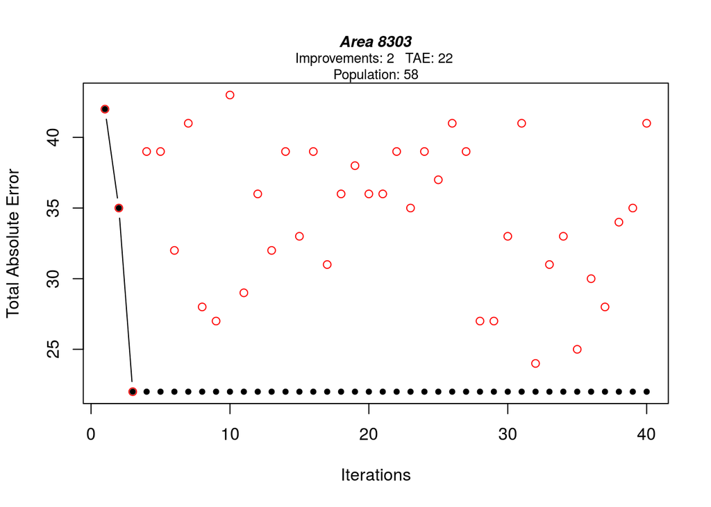

```r
plotTries(insms=try01, 3)
```

The above plot, shows the progress of TAE during the fitting process. The horizontal axis represents the iterations and the vertical the TAE. Each red circle, represents the TAE of a randomly selected combination of individuals, in each iteration. The dark filled dots, represent, the TAE of the currently selected best combination of individuals. This graph is very useful when the fitting algorithm is Simulated Annealing as it depicts the tolerance of the algorithm during the first iterations.

This was a small tutorial on preparing microdata with the use of R and the *sms* library. Please fill free to contact me regarding the *sms* library.

## Links

1. [**sms** CRAN page](http://cran.r-project.org/web/packages/sms/index.html)
2. [Sort Introduction to R and RStudio](http://cran.r-project.org/doc/contrib/Torfs+Brauer-Short-R-Intro.pdf)
3. [Install R and RStudio](http://www.slideshare.net/jmstanto/installing-r-and-rstudio)
4. [What is microsimulation](http://en.wikipedia.org/wiki/Microsimulation)
5. [My homepage](http://www.dimitrisk.gr)